# Tarea 4

Aslie Cárdenas Sandoval

2024-08-28

## Parte I

En este ejercicio usaremos la tabla de datos EjemploAlgoritmosRecomendación.csv, la cual contiene los promedios de evaluación de 100 personas que adquirieron los mismos productos o muy similares en la tienda AMAZON. La idea consiste en recomendar a un cliente los productos que ha comprado otra persona que pertenece al mismo clúster.

#### Ejercicio 1.a

Ejecute un Clustering Jerárquico con la distancia euclídea y la agregación del Salto Máximo, Salto Mínimo, Promedio y Ward. Guarde la tabla de datos en el archivo AlgoritmosRecomendación2.csv con el clúster al que pertenece cada individuo para el caso de la agregación de Ward usando 2 clústeres.

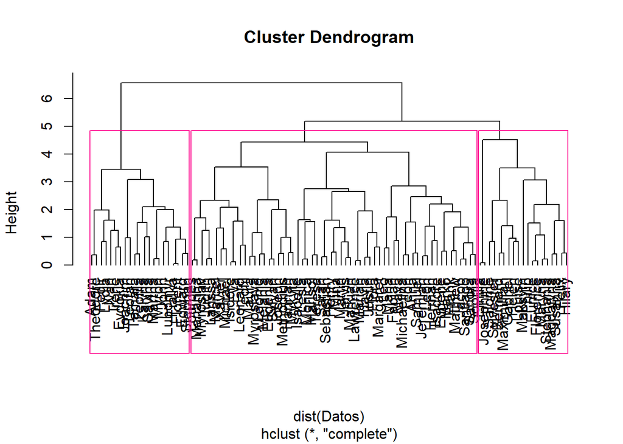

```r
Datos <- read.table("./DatosTarea4/EjemploAlgoritmosRecomendacion.csv", header = TRUE, sep = ";",dec=',', row.names = 1)

modelo.complete <- hclust(dist(Datos), method = "complete")
plot(modelo.complete, hang = -1)
rect.hclust(modelo.complete, k=3, border="#FF1493")
```

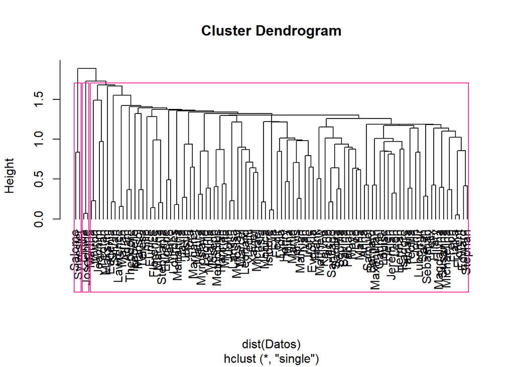

```r
modelo.single <- hclust(dist(Datos), method = "single")
plot(modelo.single, hang = -1)
rect.hclust(modelo.single, k=3, border="#FF1493")
```

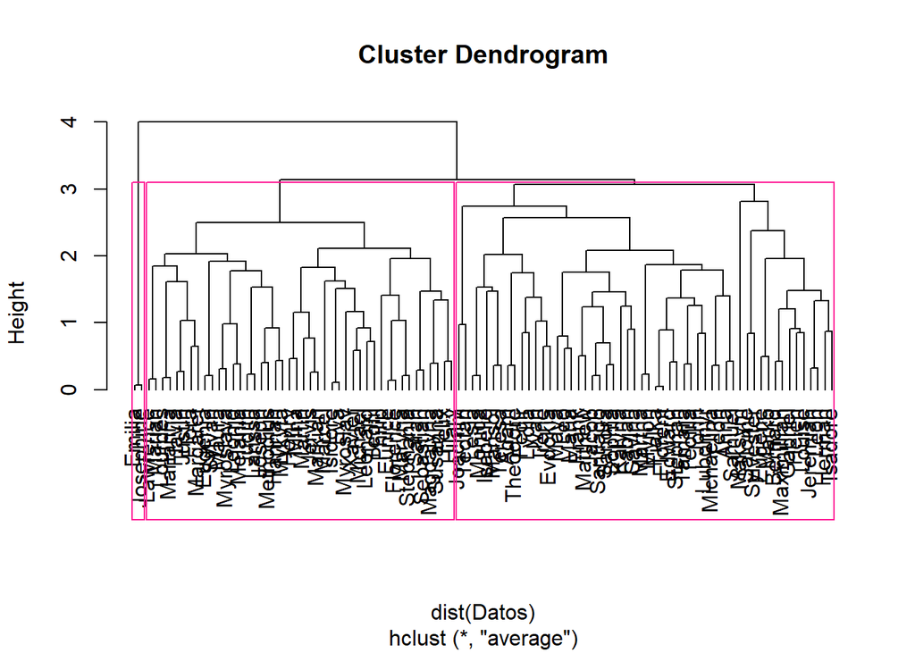

```r
modelo.average <- hclust(dist(Datos), method = "average")
plot(modelo.average, hang = -1)
rect.hclust(modelo.average, k=3, border="#FF1493")
```

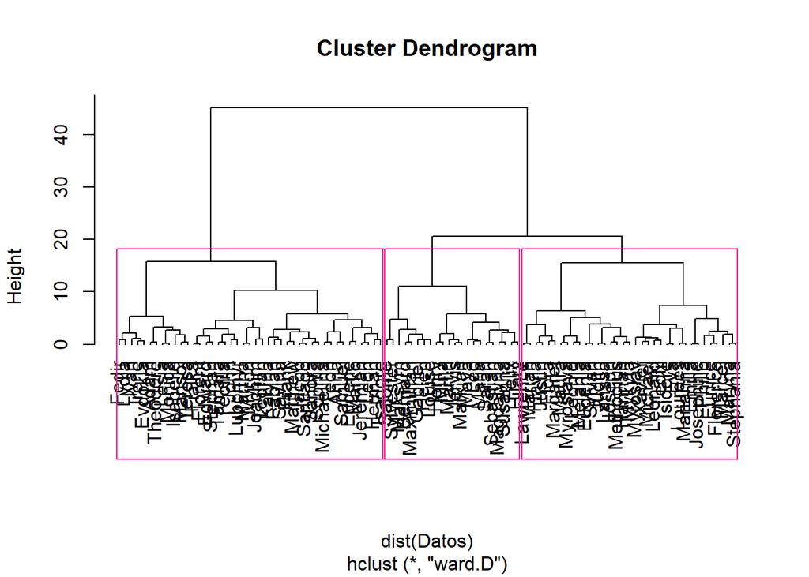

```r
modelo.ward <- hclust(dist(Datos), method = "ward.D")
plot(modelo.ward, hang = -1)
rect.hclust(modelo.ward, k=3, border="#FF1493")
```

```r
grupo <- cutree(modelo.ward, k = 2)


Datos$Grupo <- grupo

write.csv(Datos, "AlgoritmosRecomendacion2.csv", row.names = FALSE)
```

#### Ejercicio 1.b

“Corte” el árbol anterior usando 2 clústeres y la agregación de Ward, interprete los resultados usando interpretación usando gráficos de barras (Horizontal-Vertical) y usando gráficos tipo Radar.

```r
library(cluster)
library(fmsb)
# Función para encontrar el centroide de cada cluster
centroide <- function(num.cluster, datos, clusters) {
  ind <- (clusters == num.cluster)
  return(colMeans(datos[ind,]))
}

centro.cluster1 <- centroide(1, Datos, grupo)
centro.cluster2 <- centroide(2, Datos, grupo)
centros <- rbind(centro.cluster1, centro.cluster2)
centros
```

```
##                 VelocidadEntrega   Precio Durabilidad ImagenProducto
## centro.cluster1         1.262791 1.151163    3.503488       2.496512
## centro.cluster2         2.130702 1.205263    4.281579       2.720175
##                 ValorEducativo ServicioRetorno TamanoPaquete Calidad.Producto
## centro.cluster1       2.358140        2.516279      3.748837         2.019767
## centro.cluster2       3.336842        2.777193      3.286842         2.661404
##                 NumeroEstrellas Grupo
## centro.cluster1        2.288372     1
## centro.cluster2        3.729825     2
```

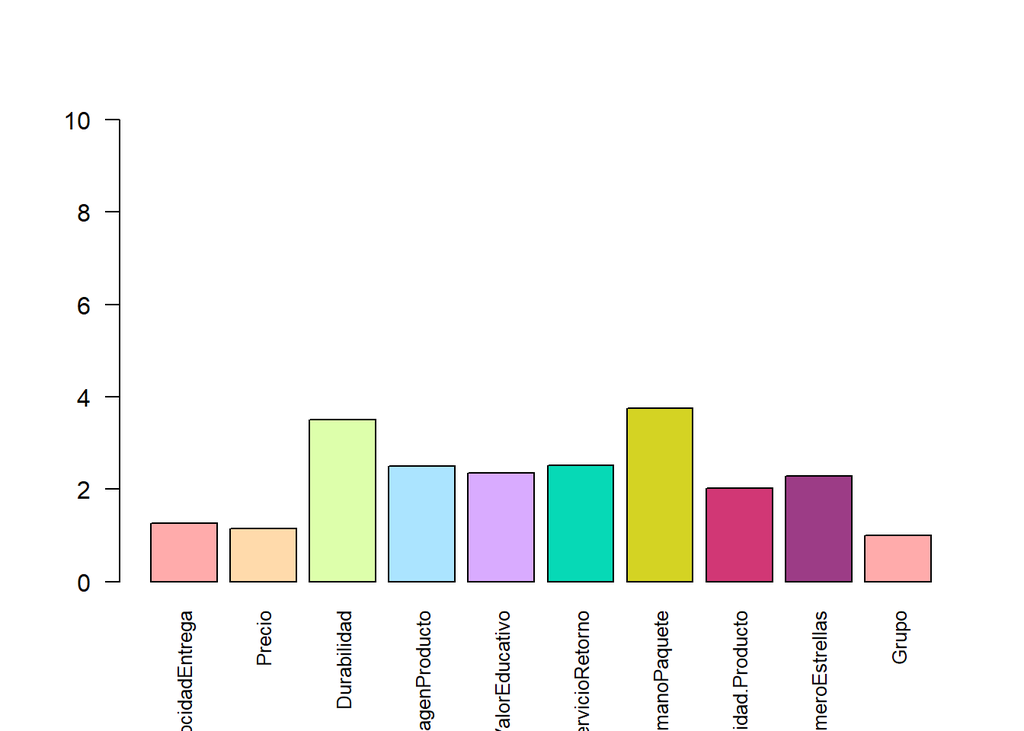

```r
paleta <- c("#ffabab", "#ffdaab", "#ddffab", "#abe4ff", "#d9abff", "#06d9b6", "#d4d323", "#d13775", "#9c3c86")
barplot(centros[1,], col=paleta, las=2, cex.names = 0.8, ylim=c(0,10))
```

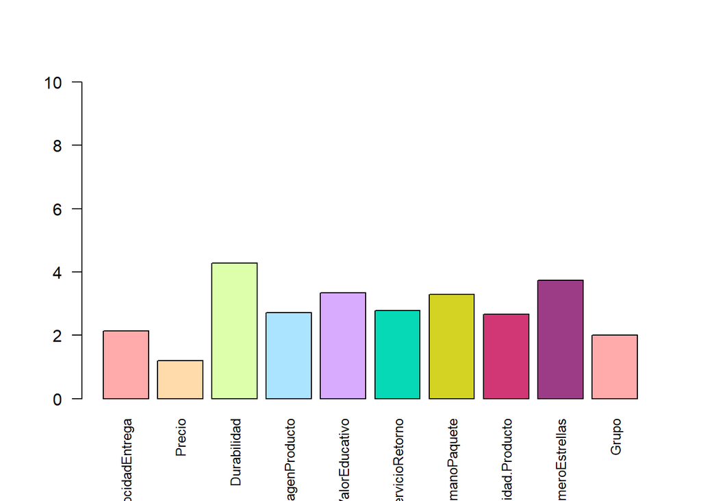

```r
barplot(centros[2,], col=paleta, las=2, cex.names = 0.8, ylim=c(0,10))
```

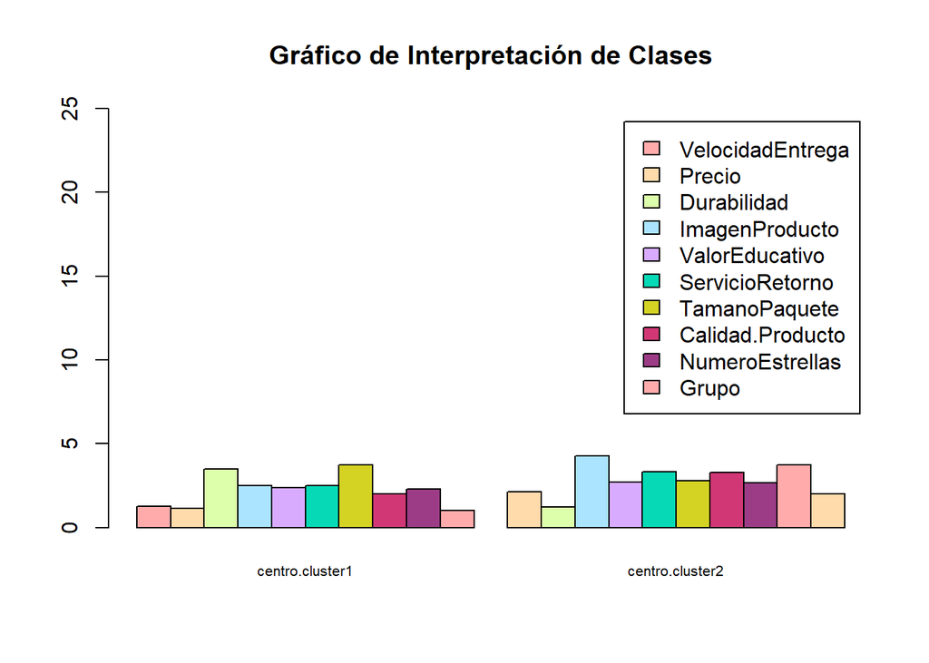

```r
barplot(t(centros),beside=TRUE,legend=colnames(Datos),main = "Gráfico de Interpretación de Clases",col=paleta, cex.names = 0.65, ylim = c(0,25))
```

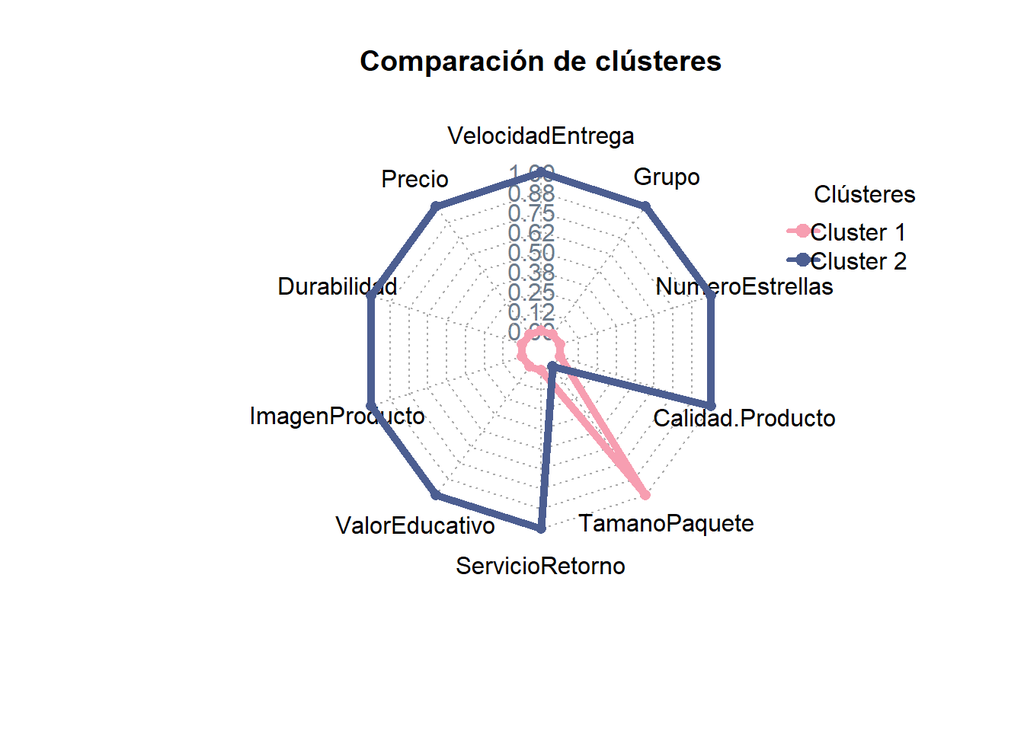

```r
centros <- as.data.frame(centros)
maximos <- apply(centros, 2, max)
minimos <- apply(centros, 2, min)
centros <- rbind(minimos, centros)
centros <- rbind(maximos, centros)




color <- c("#f79eb1","#4c5e91")
radarchart(centros,maxmin=TRUE,axistype=4,axislabcol="slategray4",
             centerzero=FALSE,seg=8, cglcol="gray67",
             pcol=color,plty=1,plwd=5,title="Comparación de clústeres")

legenda <-legend(1.5,1, legend=c("Cluster 1","Cluster 2"),
                seg.len=-1.4,title="Clústeres",pch=21,bty="n" ,lwd=3, y.intersp=1,
                horiz=FALSE,col=color)
```

#### Ejercicio 1.c

Si se tienen 4 clústeres usando agregación de Ward ¿Qué productos recomendaría a Teresa, a Leo y a Justin?, es decir, ¿los productos que compra cuál otro cliente? Usando distancia euclídea ¿cuál es la mejor recomendación de compra que le podemos hacer a Teresa, a Leo y a Justin?

```r
grupo.4 <- cutree(modelo.ward, k = 4)

clientes.cluster.1 <- rownames(Datos)[grupo.4 == 1]
print(clientes.cluster.1)
```

```
##  [1] "Adam"     "Marisol"  "Irene"    "Isabelle" "Evdokia"  "Fedir"
##  [7] "Ivan"     "Lesia"    "Lydia"    "Monica"   "Theodore" "Teresa"
```

```r
datos.cluster1 <- Datos[grupo.4 == 1, ]

#Matriz de distancias euclídeas entre todos los clientes del clúster 1
distancias.cluster1 <- dist(datos.cluster1, method = "euclidean")
distancias.matrix.cluster1 <- as.matrix(distancias.cluster1)
print(distancias.matrix.cluster1)
```

```
##               Adam   Marisol     Irene Isabelle  Evdokia     Fedir      Ivan
## Adam     0.0000000 1.5427249 1.7421251 2.085066 1.581929 1.9811613 1.9019727
## Marisol  1.5427249 0.0000000 1.7449928 1.619413 1.545154 2.0676073 2.0006249
## Irene    1.7421251 1.7449928 0.0000000 2.631064 0.650000 1.6201852 0.7952987
## Isabelle 2.0850659 1.6194135 2.6310644 0.000000 2.239420 3.2453813 3.1819805
## Evdokia  1.5819292 1.5451537 0.6500000 2.239420 0.000000 1.5787653 1.2449900
## Fedir    1.9811613 2.0676073 1.6201852 3.245381 1.578765 0.0000000 1.2854960
## Ivan     1.9019727 2.0006249 0.7952987 3.181981 1.244990 1.2854960 0.0000000
## Lesia    1.4097872 1.4823967 1.8350749 1.635543 1.394633 2.3753947 2.2649503
## Lydia    1.7102631 1.6718253 1.3209845 2.567586 1.016120 0.8485281 1.4534442
## Monica   1.5321553 1.5612495 1.9384272 1.516575 1.479865 2.5362374 2.4197107
## Theodore 0.3674235 1.6703293 1.7306068 2.409876 1.646967 1.7846568 1.7399713
## Teresa   1.6837458 0.3674235 1.9091883 1.321930 1.663580 2.3600847 2.2710130
##             Lesia     Lydia   Monica  Theodore    Teresa
## Adam     1.409787 1.7102631 1.532155 0.3674235 1.6837458
## Marisol  1.482397 1.6718253 1.561249 1.6703293 0.3674235
## Irene    1.835075 1.3209845 1.938427 1.7306068 1.9091883
## Isabelle 1.635543 2.5675864 1.516575 2.4098755 1.3219304
## Evdokia  1.394633 1.0161201 1.479865 1.6469669 1.6635805
## Fedir    2.375395 0.8485281 2.536237 1.7846568 2.3600847
## Ivan     2.264950 1.4534442 2.419711 1.7399713 2.2710130
## Lesia    0.000000 1.8391574 0.212132 1.6085708 1.4908052
## Lydia    1.839157 0.0000000 1.952562 1.6688319 1.8681542
## Monica   0.212132 1.9525624 0.000000 1.7599716 1.5206906
## Theodore 1.608571 1.6688319 1.759972 0.0000000 1.8734994
## Teresa   1.490805 1.8681542 1.520691 1.8734994 0.0000000
```

A Teresa le recomendaría los productos que compra Marisol ya que es la cliente más cercana en su mismo clúster, ella es la más parecida en cuanto a preferencias de compra.

```r
clientes.cluster.3 <- rownames(Datos)[grupo.4 == 3]
print(clientes.cluster.3)
```

```
##  [1] "Bernard"     "Gabriel"     "Henry"       "Felix"       "Helen"
##  [6] "Hilary"      "Jervis"      "Leo"         "Louise"      "Magdalyna"
## [11] "Maksym"      "Maria"       "Markian"     "Martin"      "Maya"
## [16] "Maximillian" "Mina"        "Salome"      "Sarah"       "Sebastian"
## [21] "Susanna"     "Sylvester"
```

```r
datos.cluster3 <- Datos[grupo.4 == 3, ]

distancias.cluster3 <- dist(datos.cluster3, method = "euclidean")
distancias.matrix.cluster3 <- as.matrix(distancias.cluster3)
```

A Leo le recomendaría los productos que compra María ya que es la cliente más cercana en su mismo clúster, ella es la más parecida en cuanto a preferencias de compra.

```r
clientes.cluster.4 <- rownames(Datos)[grupo.4 == 4]
print(clientes.cluster.4)
```

```
##  [1] "Emilia"    "Philip"    "Xavier"    "Isidore"   "Joseph"    "Eugenia"
##  [7] "Eunice"    "Eva"       "Flavia"    "Flora"     "Florence"  "Hannah"
## [13] "Lourdes"   "Josephine" "Judith"    "Justin"    "Larissa"   "Lawrence"
## [19] "Leonard"   "Leonid"    "Marcel"    "Margaret"  "Marian"    "Marianna"
## [25] "Maryna"    "Maura"     "Melania"   "Methodius" "Michael"   "Mykyta"
## [31] "Myroslav"  "Myroslava" "Stephania" "Sylvan"    "Teofil"
```

```r
datos.cluster4 <- Datos[grupo.4 == 4, ]

distancias.cluster4 <- dist(datos.cluster4, method = "euclidean")
distancias.matrix.cluster4 <- as.matrix(distancias.cluster4)
```

A Justin le recomendaría los productos que compra Flavia ya que es la cliente más cercana en su mismo clúster, ella es la más parecida en cuanto a preferencias de compra.

```r
recomendar.cliente <- function(cliente, datos, clusters) {
  cluster.cliente <- clusters[cliente]

  #Clientes en el mismo cluster
  datos.mismo.cluster <- datos[clusters == cluster.cliente, ]

  # Excluir al propio cliente de los datos
  datos.mismo.cluster <- datos.mismo.cluster[rownames(datos.mismo.cluster) != cliente, ]

  distancias <- dist(rbind(Datos[cliente,], datos.mismo.cluster), method = "euclidean")

  distancias.matrix <- as.matrix(distancias)[-1, 1]
  cliente.cercano <- which.min(distancias.matrix)

  nombre.cliente.cercano <- rownames(datos.mismo.cluster)[cliente.cercano]
  distancia.cliente.cercano <- distancias.matrix[cliente.cercano]

  return(list(nombre = nombre.cliente.cercano, distancia = distancia.cliente.cercano))
}


cliente.cercano.teresa <- recomendar.cliente("Teresa", Datos, grupo.4)
cliente.cercano.leo <- recomendar.cliente("Leo", Datos, grupo.4)
cliente.cercano.justin <- recomendar.cliente("Justin", Datos, grupo.4)


cat("El cliente más cercano a Teresa es", cliente.cercano.teresa$nombre, "con una distancia de", cliente.cercano.teresa$distancia, "\n")
```

```
## El cliente más cercano a Teresa es Marisol con una distancia de 0.3674235
```

```r
cat("El cliente más cercano a Leo es", cliente.cercano.leo$nombre, "con una distancia de", cliente.cercano.leo$distancia, "\n")
```

```
## El cliente más cercano a Leo es Maria con una distancia de 0.6164414
```

```r
cat("El cliente más cercano a Justin es", cliente.cercano.justin$nombre, "con una distancia de", cliente.cercano.justin$distancia, "\n")
```

```
## El cliente más cercano a Justin es Flavia con una distancia de 0.2738613
```

Por lo tanto a Teresa se le recomienda los productos que compra Marisol porque sus preferencias son las más cercanas, a Leo los de María y a Justin los que compra Flavia.

#### Ejercicio 1.d

Construya un clustering jerárquico sobre las componentes principales del ACP.

```r
library("FactoMineR")
library("factoextra")
```

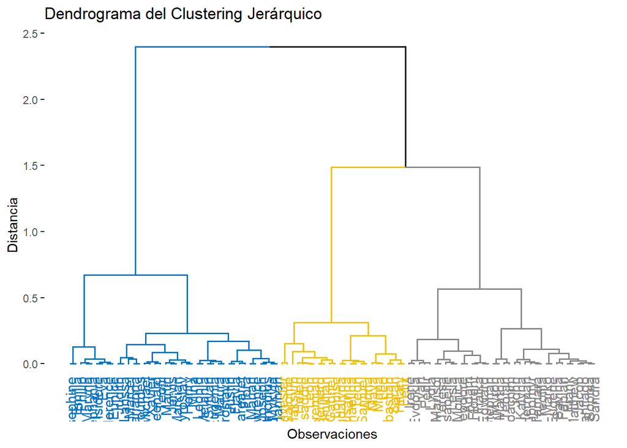

```r
library("ggplot2")
datos.recomendacion.componentes <- read.table("./DatosTarea4/EjemploAlgoritmosRecomendacion.csv", header = TRUE, sep = ";",dec=',', row.names = 1)

resultado <- PCA(datos.recomendacion.componentes, scale.unit=TRUE, ncp=5, graph = FALSE)

res.hcpc <- HCPC(resultado, nb.clust = -1, consol = TRUE, min = 3, max = 3, graph = FALSE)

suppressWarnings(
  fviz_dend(res.hcpc, k = 4, # Número de clústeres
            main = "Dendrograma del Clustering Jerárquico",
            xlab = "Observaciones",
            ylab = "Distancia",
            color_labels_by_k = TRUE,
            palette = "jco")
)
```

## Parte II

La tabla de datos VotosCongresoUS.csv la cual contiene 16 votos (y=Sí, n=No, NS=No votó) dados por los congresistas de Estados Unidos respecto a 16 temáticas diferentes, además en la primera columna aparece el partido al que pertenecen (Republicano o Demócrata).

#### Ejercicio 2.a

Ejecute una clasificación jerárquica sobre esta tabla de datos usando la función daisy ya que los datos son cualitativos. Use métrica euclidean y método complete (deje el resultado en la variable jer).

```r
library(factoextra)
library(cluster)
Datos.votos <- read.csv("./DatosTarea4/VotosCongresoUS.csv",header=TRUE, sep=",", dec=".", stringsAsFactors = TRUE)

D <- daisy(Datos.votos, metric = "euclidean")
jer <- hclust(D, method = "complete")
```

#### Ejercicio 2.b

Luego “corte” el árbol usando 3 clústeres y ejecute el siguiente código

```r
grupo<-cutree(jer, k = 3)
NDatos<-cbind(Datos.votos,grupo)
cluster<-NDatos$grupo

sel.cluster1<-match(cluster,c(1),0)
Datos.Cluster1<-NDatos[sel.cluster1>0,]
dim(Datos.Cluster1)
```

```
## [1] 232  18
```

```r
sel.cluster2<-match(cluster,c(2),0)
Datos.Cluster2<-NDatos[sel.cluster2>0,]
dim(Datos.Cluster2)
```

```
## [1] 198  18
```

```r
sel.cluster3<-match(cluster,c(3),0)
Datos.Cluster3<-NDatos[sel.cluster3>0,]
dim(Datos.Cluster3)
```

```
## [1]  5 18
```

Explique qué hace el código anterior.

El código anterior divide los datos en 3 clústeres y la informacion del número del cluster se guarda en una nueva columnna llamada grupo. Después con match() encuentramos las filas que pertenecen a un clúster específico, se selecciona las filas de los datos correspondientes al clúster y se muestra el tamaño de la dimensión de cada clúster. Por ejemplo el clúster 1 tiene una dimensión de 232 filas y 18 columnas.

Luego ejecute el siguiente código:

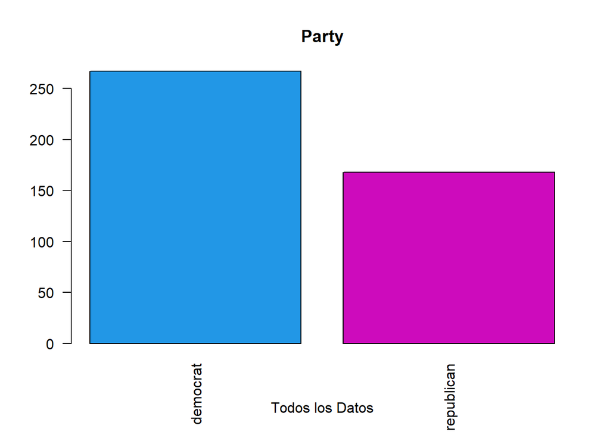

```r
plot(Datos.votos$Party,col=c(4,6),las=2,main="Party",xlab="Todos los Datos")
```

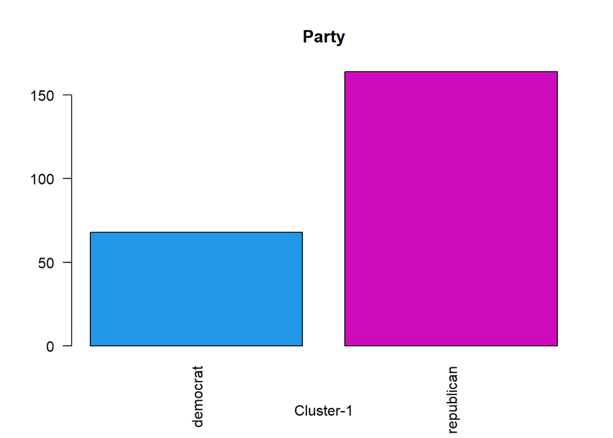

```r
plot(Datos.Cluster1$Party,col=c(4,6),las=2,main="Party",xlab="Cluster-1")
```

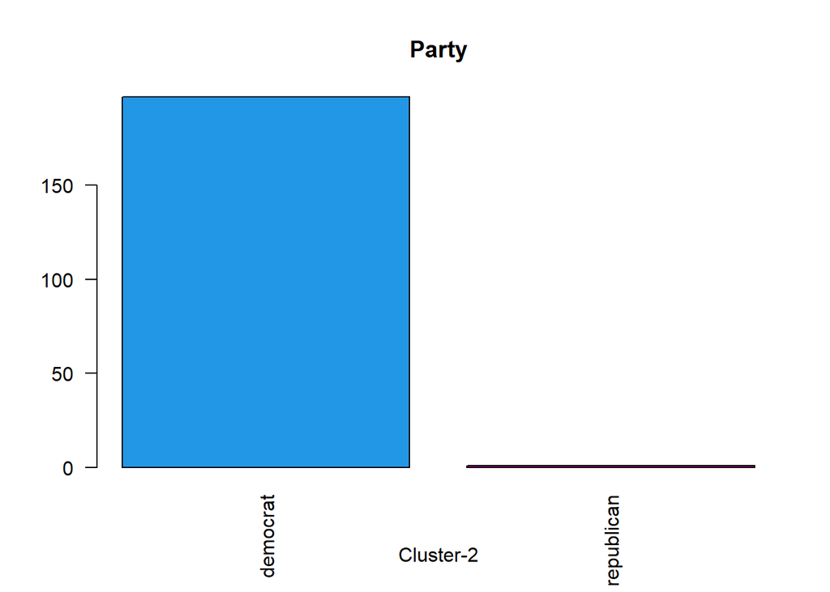

```r
plot(Datos.Cluster2$Party,col=c(4,6),las=2,main="Party",xlab="Cluster-2")
```

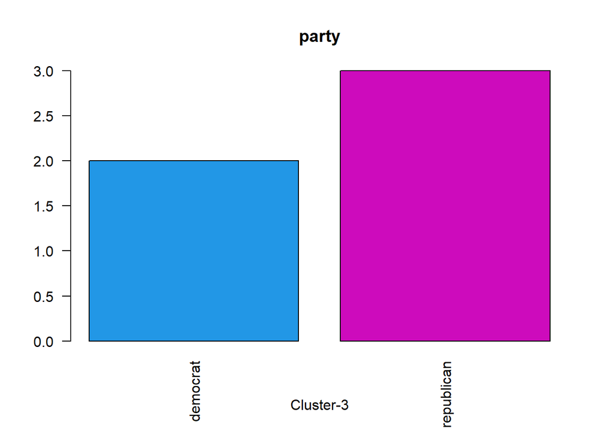

```r
plot(Datos.Cluster3$Party,col=c(4,6),las=2,main="party",xlab="Cluster-3")
```

Con ayuda de los gráficos anteriores y tomando en cuenta el tamaño de cada cluster interprete los 3 clústeres formados.

- El primer gráfico muestra la distribución de los partidos en todo el conjunto de datos. En general, hay más demócratas que republicanos en el conjunto de datos completo.
- El gráfico del clúster 1 muestra la distribución de los partidos políticos en este clúster, en este hay mayoría de republicanos sobre demócratas.
- En el gráfico del clúster 2 se agrupan principlamente los miembros demócratas del conjunto de datos. Hay una diferencia significativa ya que los republicanos son muy pocos, casi ninguno.
- El gráfico del clúster 3 es un grupo muy específico y pequeño, ya que solo hay 5 personas, 2 demócratas y 3 republicanos. La distribución es casi igual.

## Parte III

Realice un análisis similar al del ejercicio anterior con la tabla de datos CompraBicicletas.csv.

```r
Datos.bicis <- read.csv("./DatosTarea4/CompraBicicletas.csv",header=TRUE, sep=";", dec=".", stringsAsFactors = TRUE)

str(Datos.bicis)
```

```
## 'data.frame':    1000 obs. of  13 variables:
##  $ ID             : int  12496 24107 14177 24381 25597 13507 27974 19364 22155 19280 ...
##  $ MaritalStatus  : Factor w/ 2 levels "Married","Single": 1 1 1 2 2 1 2 1 1 1 ...
##  $ Gender         : Factor w/ 2 levels "Female","Male": 1 2 2 2 2 1 2 2 2 2 ...
##  $ Income         : int  40000 30000 80000 70000 30000 10000 160000 40000 20000 20000 ...
##  $ Children       : int  1 3 5 0 0 2 2 1 2 2 ...
##  $ Education      : Factor w/ 5 levels "Bachelors","GraduateDegree",..: 1 4 4 1 1 4 3 1 5 4 ...
##  $ Occupation     : Factor w/ 5 levels "Clerical","Management",..: 5 1 4 4 1 3 2 5 1 3 ...
##  $ HomeOwner      : Factor w/ 2 levels "No","Yes": 2 2 1 2 1 2 2 2 2 2 ...
##  $ Cars           : int  0 1 2 1 0 0 4 0 2 1 ...
##  $ CommuteDistance: Factor w/ 5 levels "0-1Miles","1-2Miles",..: 1 1 4 5 1 2 1 1 5 1 ...
##  $ Region         : Factor w/ 3 levels "Europe","NorthAmerica",..: 1 1 1 3 1 1 3 1 3 1 ...
##  $ Age            : int  42 43 60 41 36 50 33 43 58 48 ...
##  $ PurchasedBike  : Factor w/ 2 levels "No","Yes": 1 1 1 2 2 1 2 2 1 2 ...
```

```r
Da <- daisy(Datos.bicis, metric = "euclidean")
jer <- hclust(Da, method = "complete")
grupos.b <- cutree(jer, k=3)
centro.cluster1.b<-centroide(1, Datos.bicis[,-c(1,2,3,6,7,8,10,11,13)],grupos.b)

centro.cluster2.b<-centroide(2, Datos.bicis[,-c(1,2,3,6,7,8,10,11,13)],grupos.b)

centro.cluster3.b<-centroide(3, Datos.bicis[,-c(1,2,3,6,7,8,10,11,13)],grupos.b)

centros<-rbind(centro.cluster1.b, centro.cluster2.b, centro.cluster3.b)

centros<-as.data.frame(centros)
maximos<-apply(centros, 2, max)
minimos<-apply(centros, 2, min)
centros<-rbind(minimos, centros)
centros<-rbind(maximos, centros)
centros
```

```
##                     Income Children     Cars      Age
## 1                 90243.90 2.384401 2.455285 47.41504
## 11                41640.93 1.494208 1.028958 41.90927
## centro.cluster1.b 41640.93 1.494208 1.028958 41.90927
## centro.cluster2.b 90243.90 2.260163 2.455285 44.38211
## centro.cluster3.b 65376.04 2.384401 1.718663 47.41504
```

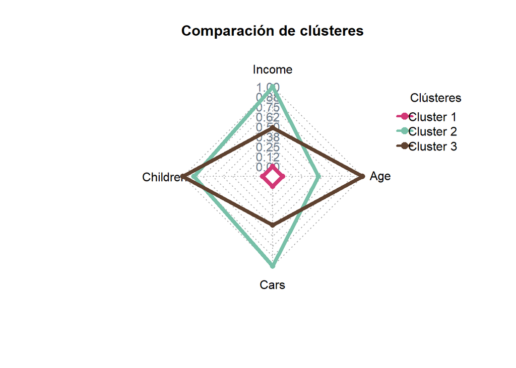

```r
color <- c("#d13775","#78C0A8","#5E412F")

radarchart(as.data.frame(centros),maxmin=TRUE,axistype=4,axislabcol="slategray4",
             centerzero=FALSE,seg=8, cglcol="gray67",
             pcol=color,plty=1,plwd=5,title="Comparación de clústeres")

legenda <-legend(1.5,1, legend=c("Cluster 1","Cluster 2","Cluster 3"),
                seg.len=-1.4,title="Clústeres",pch=21,bty="n" ,lwd=3, y.intersp=1,
                horiz=FALSE,col=color)
```

Interpretación:

```r
grupo <- cutree(jer, k=3)
NDatos<- cbind(Datos.bicis, grupo)
cluster <- NDatos$grupo

sel.cluster1<-match(cluster,c(1),0)
Datos.Cluster1<-NDatos[sel.cluster1>0,]
dim(Datos.Cluster1)
```

```
## [1] 518  14
```

```r
sel.cluster2<-match(cluster,c(2),0)
Datos.Cluster2<-NDatos[sel.cluster2>0,]
dim(Datos.Cluster2)
```

```
## [1] 123  14
```

```r
sel.cluster3<-match(cluster,c(3),0)
Datos.Cluster3<-NDatos[sel.cluster3>0,]
dim(Datos.Cluster3)
```

```
## [1] 359  14
```

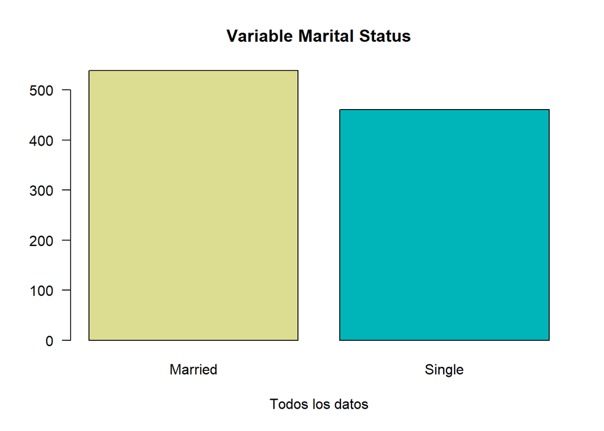

```r
color1 <- c("#f97992", "#231b42")
color2 <- c("#dddd92", "#00b5b9")
color3 <- c("#ef9ca4", "#c4ddd6")
color4 <- c("#5adb94", "#0ba18c", "#8a034d")
color5 <- c("#fa8cb1", "#fdc5c9", "#fffee1", "#cfb699", "#9e6d4e")
color6 <- c("#fffab3", "#a2e5d2", "#63b397", "#9dab34", "#2c2321")



plot(Datos.bicis$MaritalStatus, col = color2, las = 1, main = "Variable Marital Status", xlab = "Todos los datos")
```

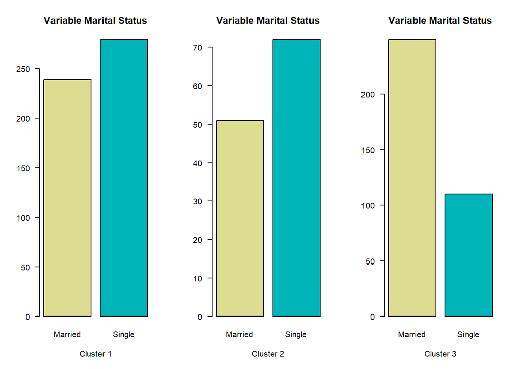

```r
par(mfrow = c(1, 3))
plot(Datos.Cluster1$MaritalStatus, col = color2, las = 1, main = "Variable Marital Status", xlab = "Cluster 1")
plot(Datos.Cluster2$MaritalStatus, col = color2, las = 1, main = "Variable Marital Status", xlab = "Cluster 2")
plot(Datos.Cluster3$MaritalStatus, col = color2, las = 1, main = "Variable Marital Status", xlab = "Cluster 3")
```

```r
par(mfrow = c(1, 1))
```

- En el clúster 1 y el clúster 2 la mayoría de personas son solteras.
- En el clúster 3 la mayoría son casadas.

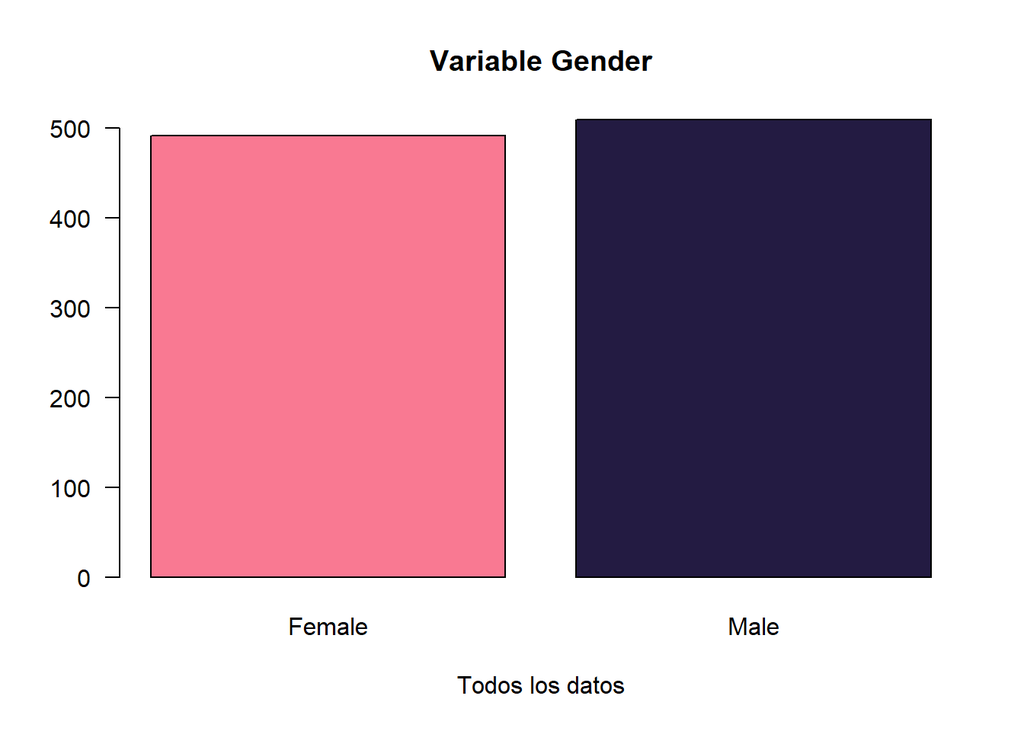

```r
plot(Datos.bicis$Gender, col = color1, las = 1, main = "Variable Gender", xlab = "Todos los datos")
```

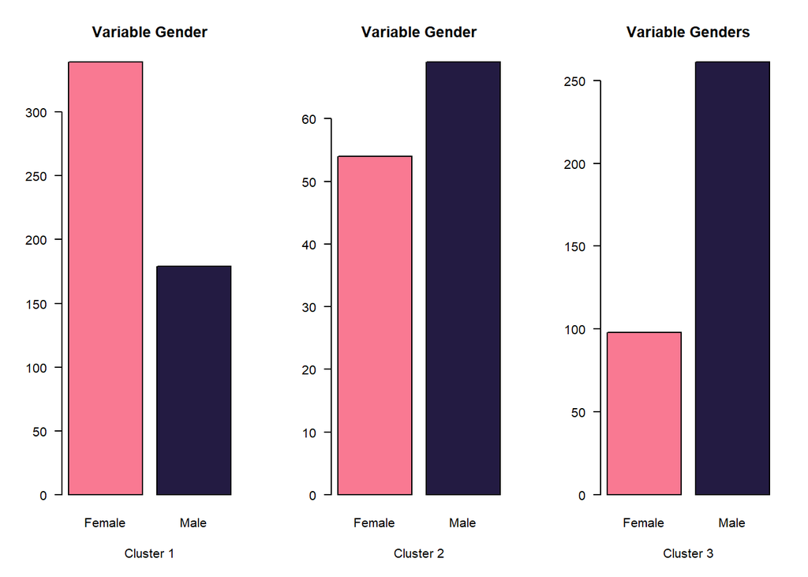

```r
par(mfrow = c(1, 3))
plot(Datos.Cluster1$Gender, col = color1, las = 1, main = "Variable Gender", xlab = "Cluster 1")
plot(Datos.Cluster2$Gender, col = color1, las = 1, main = "Variable Gender", xlab = "Cluster 2")
plot(Datos.Cluster3$Gender, col = color1, las = 1, main = "Variable Genders", xlab = "Cluster 3")
```

```r
par(mfrow = c(1, 1))
```

- En el clúster 1 la mayoría de personas son mujeres.
- En el clúster 2 y el clúster 3 son más hombres.

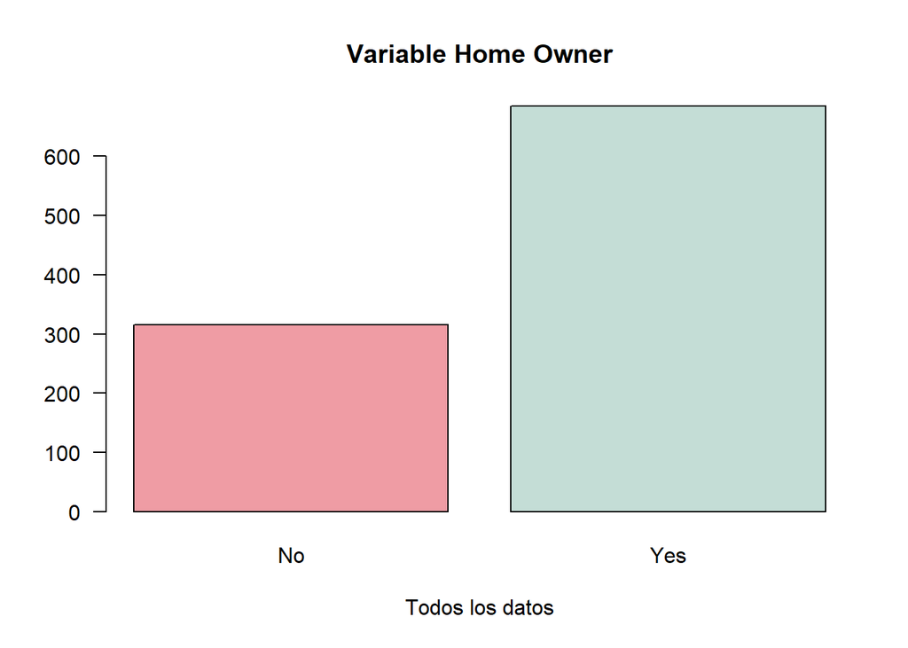

```r
plot(Datos.bicis$HomeOwner, col = color3, las = 1, main = "Variable Home Owner", xlab = "Todos los datos")
```

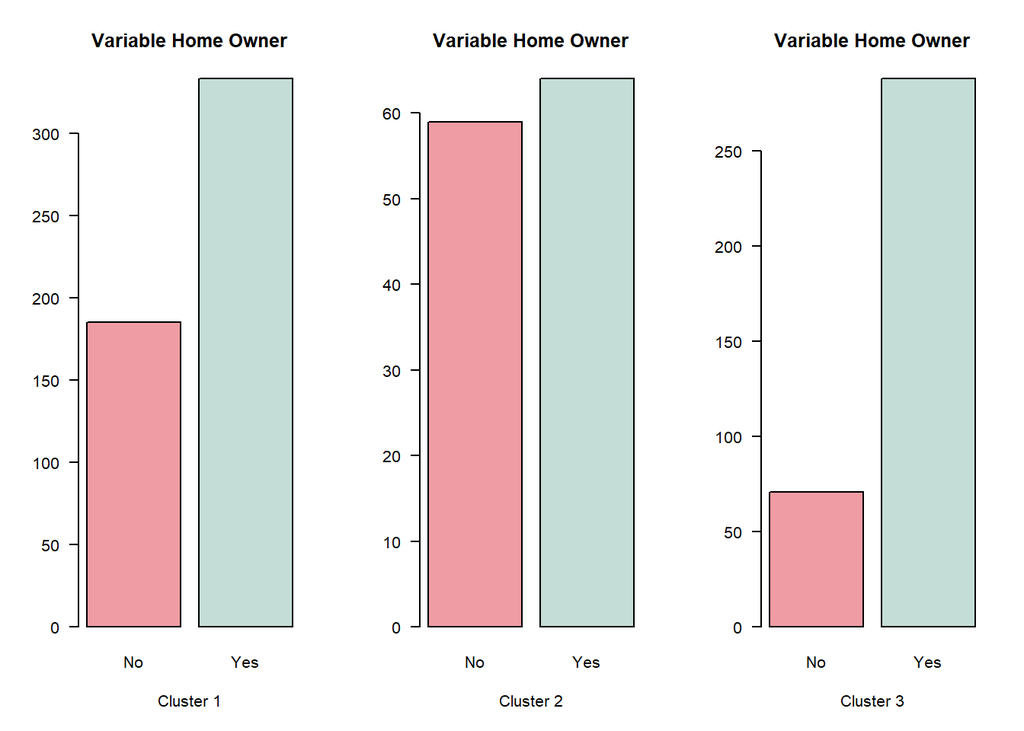

```r
par(mfrow = c(1, 3))
plot(Datos.Cluster1$HomeOwner, col = color3, las = 1, main = "Variable Home Owner", xlab = "Cluster 1")
plot(Datos.Cluster2$HomeOwner, col = color3, las = 1, main = "Variable Home Owner", xlab = "Cluster 2")
plot(Datos.Cluster3$HomeOwner, col = color3, las = 1, main = "Variable Home Owner", xlab = "Cluster 3")
```

```r
par(mfrow = c(1, 1))
```

- Del clúster 1 y el clúster 3 la mayor parte de los individuos son dueños de casa.
- En el clúster 3 predomina más que sean dueños de casas.
- En el clúster 2 la diferencia es poca entre quien posee y no una casa.

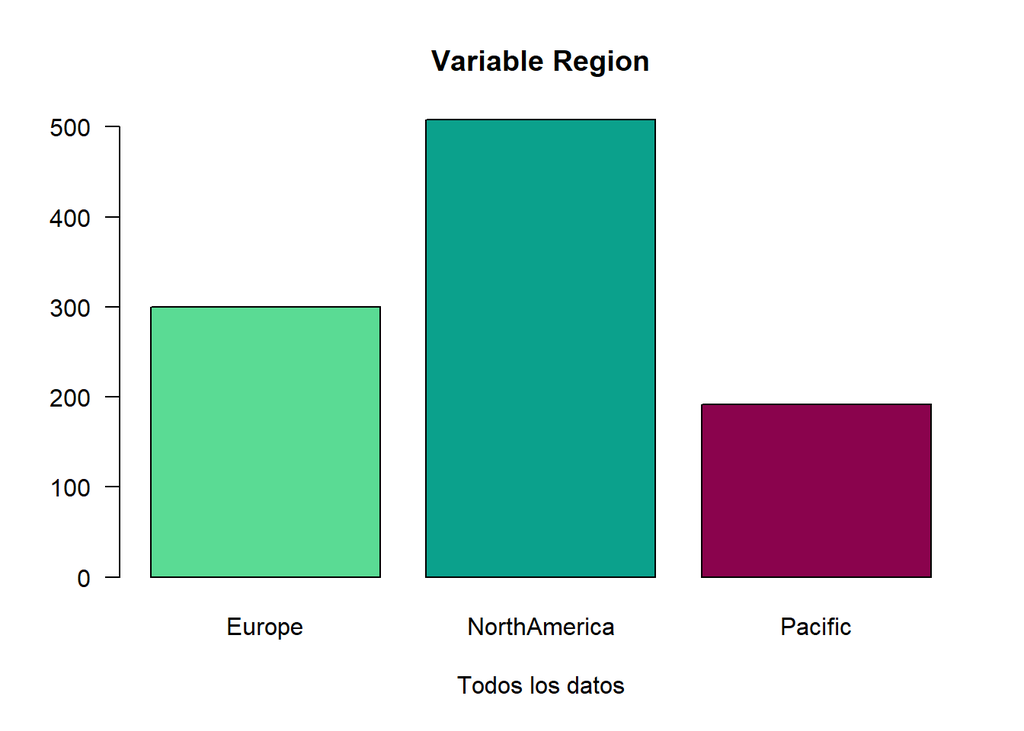

```r
plot(Datos.bicis$Region, col = color4, las = 1, main = "Variable Region", xlab = "Todos los datos")
```

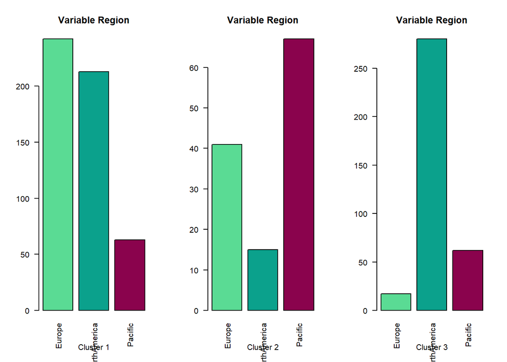

```r
par(mfrow = c(1, 3))
plot(Datos.Cluster1$Region, col = color4, las = 2, main = "Variable Region", xlab = "Cluster 1")
plot(Datos.Cluster2$Region, col = color4, las = 2, main = "Variable Region", xlab = "Cluster 2")
plot(Datos.Cluster3$Region, col = color4, las = 2, main = "Variable Region", xlab = "Cluster 3")
```

```r
par(mfrow = c(1, 1))
```

- En el clúster 1 la mayoría de los individuos son de Europa.
- En el clúster 2 predomina más el que sean del pacífico.
- En el clúster 3 hay más individuos de norte américa.

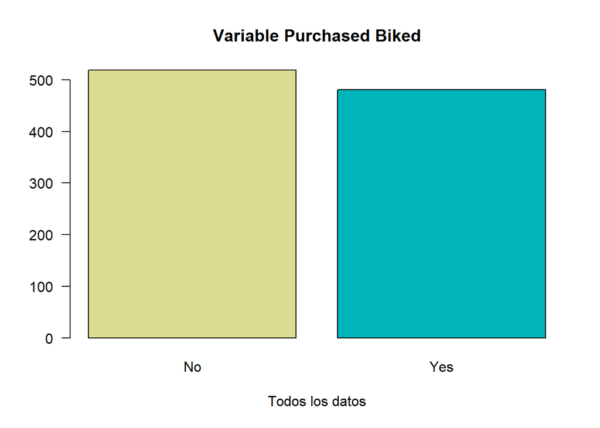

```r
plot(Datos.bicis$PurchasedBike, col = color2, las = 1, main = "Variable Purchased Biked", xlab = "Todos los datos")
```

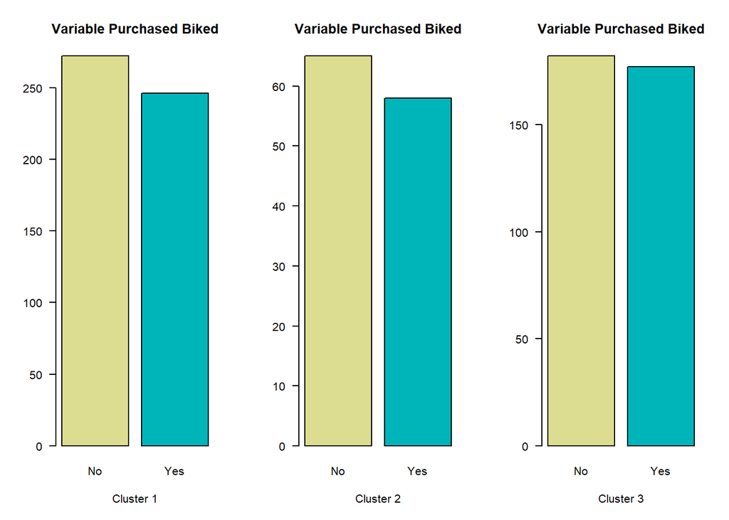

```r
par(mfrow = c(1, 3))
plot(Datos.Cluster1$PurchasedBike, col = color2, las = 1, main = "Variable Purchased Biked", xlab = "Cluster 1")
plot(Datos.Cluster2$PurchasedBike, col = color2, las = 1, main = "Variable Purchased Biked", xlab = "Cluster 2")
plot(Datos.Cluster3$PurchasedBike, col = color2, las = 1, main = "Variable Purchased Biked", xlab = "Cluster 3")
```

```r
par(mfrow = c(1, 1))
```

- Los 3 clústeres se mantienen equilibrados en cuanto a si el individuo compró o no una bicicleta, sin embargo en los 3 clústeres predomina por poco el que no hayan comprado.

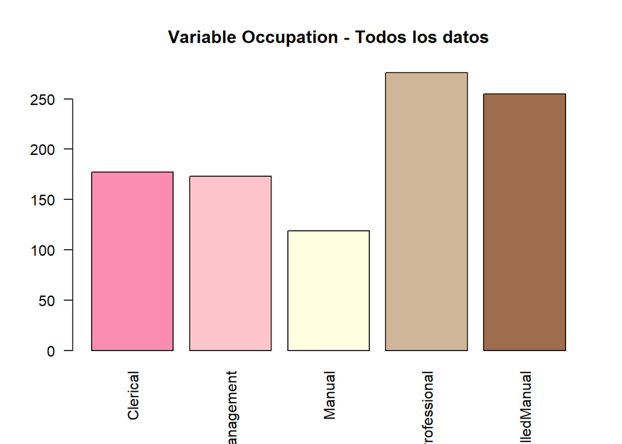

```r
plot(Datos.bicis$Occupation, col = color5, las = 2, main = "Variable Occupation - Todos los datos")
```

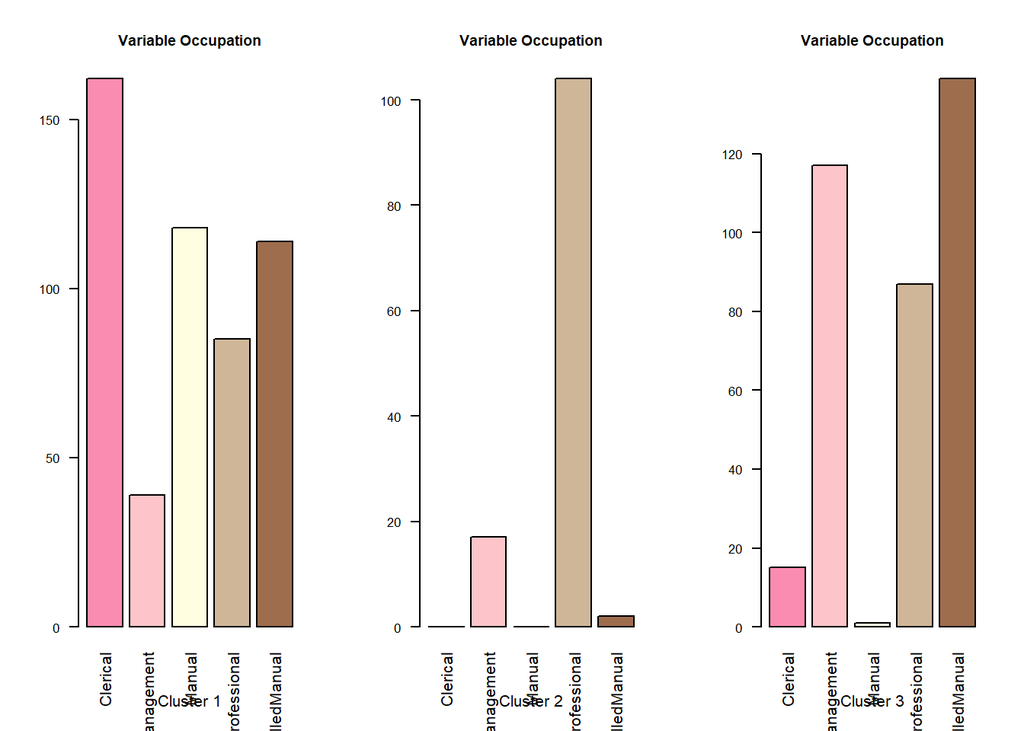

```r
layout(matrix(1:3, nrow = 1, ncol = 3))
plot(Datos.Cluster1$Occupation, col = color5, las = 2, main = "Variable Occupation", xlab = "Cluster 1", cex.axis = 0.8, cex.main = 0.9)
plot(Datos.Cluster2$Occupation, col = color5, las = 2, main = "Variable Occupation", xlab = "Cluster 2", cex.axis = 0.8, cex.main = 0.9)
plot(Datos.Cluster3$Occupation, col = color5, las = 2, main = "Variable Occupation", xlab = "Cluster 3", cex.axis = 0.8, cex.main = 0.9)
```

```r
layout(1)
```

- En el clúster 1 hay más personas con ocupación clerical o tipo administrativa, también sobresale el trabajo manual.
- En el clúster 2 la mayoría tiene una ocupación de profesional y un poco de gerencial(managment)
- El clúster 3 es más variado, sobresalen las ocupaciones skilled manual, gerencial y profesional.

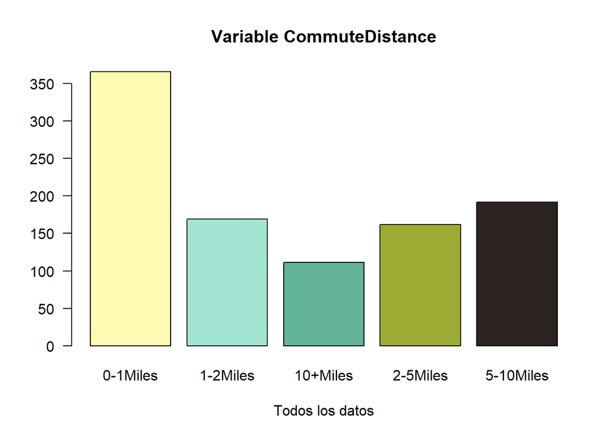

```r
plot(Datos.bicis$CommuteDistance, col = color6, las = 1, main = "Variable CommuteDistance", xlab = "Todos los datos")
```

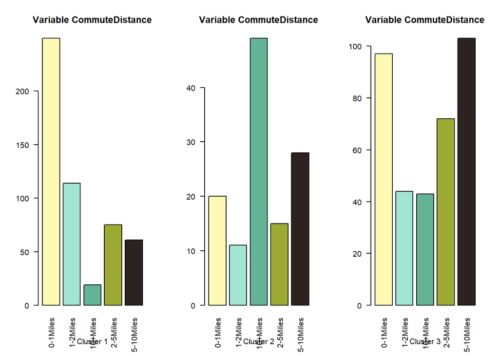

```r
par(mfrow = c(1, 3))
plot(Datos.Cluster1$CommuteDistance, col = color6, las = 2, main = "Variable CommuteDistance", xlab = "Cluster 1")
plot(Datos.Cluster2$CommuteDistance, col = color6, las = 2, main = "Variable CommuteDistance", xlab = "Cluster 2")
plot(Datos.Cluster3$CommuteDistance, col = color6, las = 2, main = "Variable CommuteDistance", xlab = "Cluster 3")
```

```r
par(mfrow = c(1, 1))
```

- El clúster 1 incluye individuos que viven muy cerca de su lugar de trabajo, con distancias de desplazamiento muy cortas, de entre 0 y 1 milla.
- El clúster 2 agrupa a individuos que viven a una distancia considerable de su lugar de trabajo, más de 10 millas.
- El clúster 3 incluye individuos que viven a una distancia moderada de su lugar de trabajo, entre 5 y 10 millas y también individuos que viven cerca de su lugar de trabajp entre 0 y 1 milla.

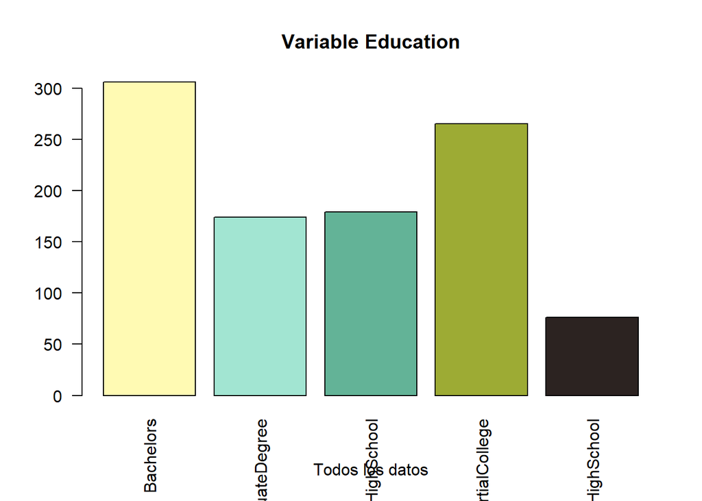

```r
plot(Datos.bicis$Education, col = color6, las = 2, main = "Variable Education", xlab = "Todos los datos")
```

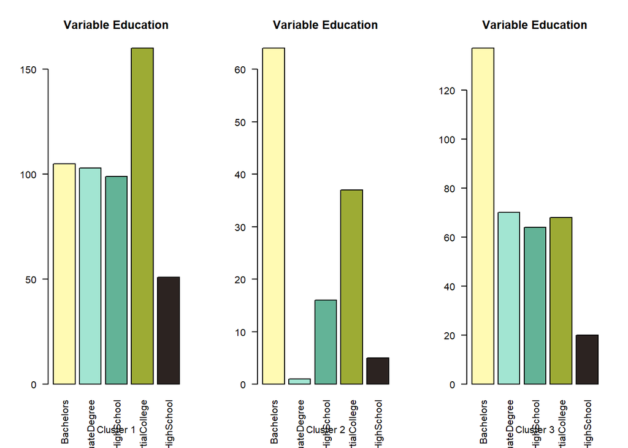

```r
par(mfrow = c(1, 3))
plot(Datos.Cluster1$Education, col = color6, las = 2, main = "Variable Education", xlab = "Cluster 1")
plot(Datos.Cluster2$Education, col = color6, las = 2, main = "Variable Education", xlab = "Cluster 2")
plot(Datos.Cluster3$Education, col = color6, las = 2, main = "Variable Education", xlab = "Cluster 3")
```

```r
par(mfrow = c(1, 1))
```

- Por último en el clúster 1 el rango más alto en educación es universidad incompleta(Partial college).
- En el clúster 2 están personas con un nivel más alto con un título universitario(Bachelors).
- En el clúster 3 está parecido al clúster 2, pero hay más personas con Posgrado que en el clúster 2.

## Parte IV

Dada la siguiente matriz de disimilitudes entre cuatroindividuos A1, A2, A3 y A4, construya “a mano” una Jerarquía Binaria usando la agregación del Salto Máximo y del Promedio, dibuje el dendograma en ambos casos.

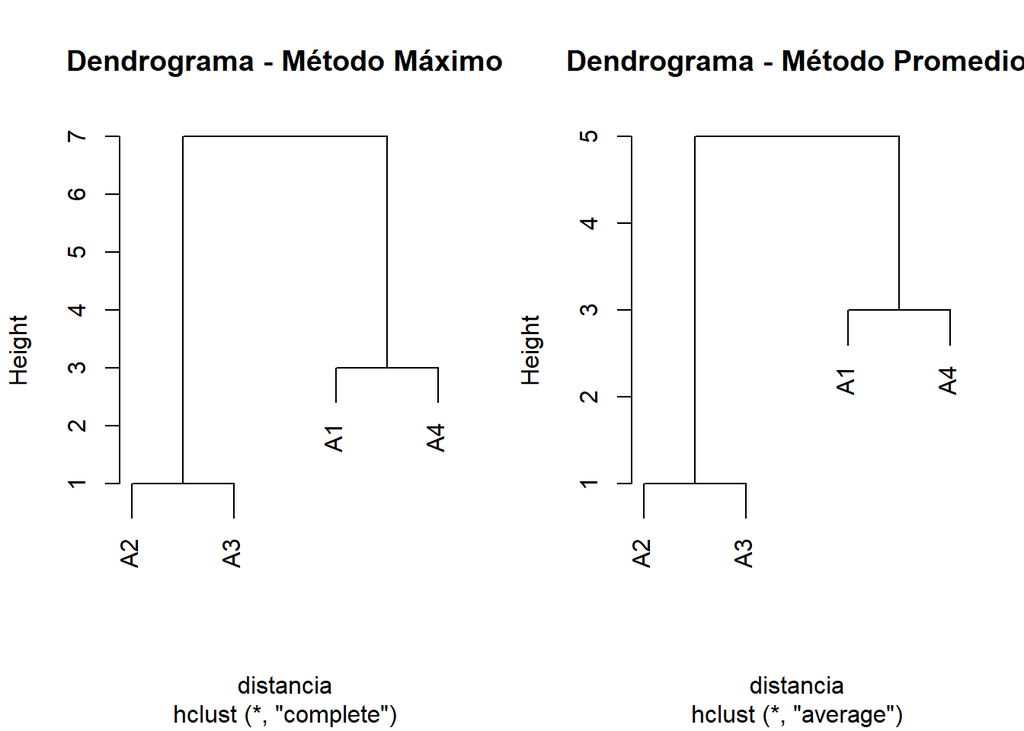

```r
D <- matrix(c(0, 5, 2, 3,
              5, 0, 1, 7,
              2, 1, 0, 6,
              3, 7, 6, 0), nrow=4, byrow=TRUE)

rownames(D) <- colnames(D) <- c("A1", "A2", "A3", "A4")

distancia <- as.dist(D)


salto.maximo <- hclust(distancia, method = "complete")

salto.promedio <- hclust(distancia, method = "average")

par(mfrow=c(1,2))
plot(salto.maximo, main="Dendrograma - Método Máximo")
plot(salto.promedio, main="Dendrograma - Método Promedio")
```